# W5 python project

## Part 1

### 1. Import required libraries and read the dataset.

```python
import pandas as pd
import numpy as np
import seaborn as sns
import matplotlib.pyplot as plt
from sklearn.linear_model import LinearRegression
from sklearn.model_selection import train_test_split
from sklearn.preprocessing import LabelEncoder
from sklearn.preprocessing import MinMaxScaler
```

```python
f1 = pd.read_csv("Apps_data+(1).csv")
f1
```

|  | App | Category | Rating | Reviews | Size | Installs | Type | Price | Content Rating | Genres | Last Updated | Current Ver | Android Ver |
| --- | --- | --- | --- | --- | --- | --- | --- | --- | --- | --- | --- | --- | --- |
| 0 | Photo Editor & Candy Camera & Grid & ScrapBook | ART_AND_DESIGN | 4.1 | 159 | 19M | 10,000+ | Free | 0 | Everyone | Art & Design | January 7, 2018 | 1.0.0 | 4.0.3 and up |
| 1 | Coloring book moana | ART_AND_DESIGN | 3.9 | 967 | 14M | 500,000+ | Free | 0 | Everyone | Art & Design;Pretend Play | January 15, 2018 | 2.0.0 | 4.0.3 and up |
| 2 | U Launcher Lite – FREE Live Cool Themes, Hide ... | ART_AND_DESIGN | 4.7 | 87510 | 8.7M | 5,000,000+ | Free | 0 | Everyone | Art & Design | August 1, 2018 | 1.2.4 | 4.0.3 and up |
| 3 | Sketch - Draw & Paint | ART_AND_DESIGN | 4.5 | 215644 | 25M | 50,000,000+ | Free | 0 | Teen | Art & Design | June 8, 2018 | Varies with device | 4.2 and up |
| 4 | Pixel Draw - Number Art Coloring Book | ART_AND_DESIGN | 4.3 | 967 | 2.8M | 100,000+ | Free | 0 | Everyone | Art & Design;Creativity | June 20, 2018 | 1.1 | 4.4 and up |
| ... | ... | ... | ... | ... | ... | ... | ... | ... | ... | ... | ... | ... | ... |
| 10836 | Sya9a Maroc - FR | FAMILY | 4.5 | 38 | 53M | 5,000+ | Free | 0 | Everyone | Education | July 25, 2017 | 1.48 | 4.1 and up |
| 10837 | Fr. Mike Schmitz Audio Teachings | FAMILY | 5.0 | 4 | 3.6M | 100+ | Free | 0 | Everyone | Education | July 6, 2018 | 1.0 | 4.1 and up |
| 10838 | Parkinson Exercices FR | MEDICAL | NaN | 3 | 9.5M | 1,000+ | Free | 0 | Everyone | Medical | January 20, 2017 | 1.0 | 2.2 and up |
| 10839 | The SCP Foundation DB fr nn5n | BOOKS_AND_REFERENCE | 4.5 | 114 | Varies with device | 1,000+ | Free | 0 | Mature 17+ | Books & Reference | January 19, 2015 | Varies with device | Varies with device |
| 10840 | iHoroscope - 2018 Daily Horoscope & Astrology | LIFESTYLE | 4.5 | 398307 | 19M | 10,000,000+ | Free | 0 | Everyone | Lifestyle | July 25, 2018 | Varies with device | Varies with device |

10841 rows × 13 columns

### 2. Check the first few samples, shape, info of the data and try to familiarize yourself with different features

```python
f1.head(10)
```

|  | App | Category | Rating | Reviews | Size | Installs | Type | Price | Content Rating | Genres | Last Updated | Current Ver | Android Ver |
| --- | --- | --- | --- | --- | --- | --- | --- | --- | --- | --- | --- | --- | --- |
| 0 | Photo Editor & Candy Camera & Grid & ScrapBook | ART_AND_DESIGN | 4.1 | 159 | 19M | 10,000+ | Free | 0 | Everyone | Art & Design | January 7, 2018 | 1.0.0 | 4.0.3 and up |
| 1 | Coloring book moana | ART_AND_DESIGN | 3.9 | 967 | 14M | 500,000+ | Free | 0 | Everyone | Art & Design;Pretend Play | January 15, 2018 | 2.0.0 | 4.0.3 and up |
| 2 | U Launcher Lite – FREE Live Cool Themes, Hide ... | ART_AND_DESIGN | 4.7 | 87510 | 8.7M | 5,000,000+ | Free | 0 | Everyone | Art & Design | August 1, 2018 | 1.2.4 | 4.0.3 and up |
| 3 | Sketch - Draw & Paint | ART_AND_DESIGN | 4.5 | 215644 | 25M | 50,000,000+ | Free | 0 | Teen | Art & Design | June 8, 2018 | Varies with device | 4.2 and up |
| 4 | Pixel Draw - Number Art Coloring Book | ART_AND_DESIGN | 4.3 | 967 | 2.8M | 100,000+ | Free | 0 | Everyone | Art & Design;Creativity | June 20, 2018 | 1.1 | 4.4 and up |
| 5 | Paper flowers instructions | ART_AND_DESIGN | 4.4 | 167 | 5.6M | 50,000+ | Free | 0 | Everyone | Art & Design | March 26, 2017 | 1.0 | 2.3 and up |
| 6 | Smoke Effect Photo Maker - Smoke Editor | ART_AND_DESIGN | 3.8 | 178 | 19M | 50,000+ | Free | 0 | Everyone | Art & Design | April 26, 2018 | 1.1 | 4.0.3 and up |
| 7 | Infinite Painter | ART_AND_DESIGN | 4.1 | 36815 | 29M | 1,000,000+ | Free | 0 | Everyone | Art & Design | June 14, 2018 | 6.1.61.1 | 4.2 and up |
| 8 | Garden Coloring Book | ART_AND_DESIGN | 4.4 | 13791 | 33M | 1,000,000+ | Free | 0 | Everyone | Art & Design | September 20, 2017 | 2.9.2 | 3.0 and up |
| 9 | Kids Paint Free - Drawing Fun | ART_AND_DESIGN | 4.7 | 121 | 3.1M | 10,000+ | Free | 0 | Everyone | Art & Design;Creativity | July 3, 2018 | 2.8 | 4.0.3 and up |

```python
f1.dtypes
```

```
App                object
Category           object
Rating            float64
Reviews            object
Size               object
Installs           object
Type               object
Price              object
Content Rating     object
Genres             object
Last Updated       object
Current Ver        object
Android Ver        object
dtype: object
```

```python
f1.shape
```

```
(10841, 13)
```

```python
f1.info()
```

```
<class 'pandas.core.frame.DataFrame'>
RangeIndex: 10841 entries, 0 to 10840
Data columns (total 13 columns):
 #   Column          Non-Null Count  Dtype
---  ------          --------------  -----
 0   App             10841 non-null  object
 1   Category        10841 non-null  object
 2   Rating          9367 non-null   float64
 3   Reviews         10841 non-null  object
 4   Size            10841 non-null  object
 5   Installs        10841 non-null  object
 6   Type            10840 non-null  object
 7   Price           10841 non-null  object
 8   Content Rating  10840 non-null  object
 9   Genres          10841 non-null  object
 10  Last Updated    10841 non-null  object
 11  Current Ver     10833 non-null  object
 12  Android Ver     10838 non-null  object
dtypes: float64(1), object(12)
memory usage: 1.1+ MB
```

### 3. Check summary statistics of the dataset. List out the columns that need to be worked upon for model building

```python
f1.describe(include="all")
```

|  | App | Category | Rating | Reviews | Size | Installs | Type | Price | Content Rating | Genres | Last Updated | Current Ver | Android Ver |
| --- | --- | --- | --- | --- | --- | --- | --- | --- | --- | --- | --- | --- | --- |
| count | 10841 | 10841 | 9367.000000 | 10841 | 10841 | 10841 | 10840 | 10841 | 10840 | 10841 | 10841 | 10833 | 10838 |
| unique | 9660 | 34 | NaN | 6002 | 462 | 22 | 3 | 93 | 6 | 120 | 1378 | 2832 | 33 |
| top | ROBLOX | FAMILY | NaN | 0 | Varies with device | 1,000,000+ | Free | 0 | Everyone | Tools | August 3, 2018 | Varies with device | 4.1 and up |
| freq | 9 | 1972 | NaN | 596 | 1695 | 1579 | 10039 | 10040 | 8714 | 842 | 326 | 1459 | 2451 |
| mean | NaN | NaN | 4.193338 | NaN | NaN | NaN | NaN | NaN | NaN | NaN | NaN | NaN | NaN |
| std | NaN | NaN | 0.537431 | NaN | NaN | NaN | NaN | NaN | NaN | NaN | NaN | NaN | NaN |
| min | NaN | NaN | 1.000000 | NaN | NaN | NaN | NaN | NaN | NaN | NaN | NaN | NaN | NaN |
| 25% | NaN | NaN | 4.000000 | NaN | NaN | NaN | NaN | NaN | NaN | NaN | NaN | NaN | NaN |
| 50% | NaN | NaN | 4.300000 | NaN | NaN | NaN | NaN | NaN | NaN | NaN | NaN | NaN | NaN |
| 75% | NaN | NaN | 4.500000 | NaN | NaN | NaN | NaN | NaN | NaN | NaN | NaN | NaN | NaN |
| max | NaN | NaN | 19.000000 | NaN | NaN | NaN | NaN | NaN | NaN | NaN | NaN | NaN | NaN |

### 4. Check if there are any duplicate records in the dataset? if any drop them.

```python
f1.duplicated().sum()
```

```
483
```

```python
f1.drop_duplicates(inplace=True)
```

```python
f1.duplicated().sum()
```

```
0
```

### 5. Check the unique categories of the column 'Category', Is there any invalid category? If yes, drop them.

```python
unique_value = f1['Category'].unique()
unique_value
```

```
array(['ART_AND_DESIGN', 'AUTO_AND_VEHICLES', 'BEAUTY',
       'BOOKS_AND_REFERENCE', 'BUSINESS', 'COMICS', 'COMMUNICATION',
       'DATING', 'EDUCATION', 'ENTERTAINMENT', 'EVENTS', 'FINANCE',
       'FOOD_AND_DRINK', 'HEALTH_AND_FITNESS', 'HOUSE_AND_HOME',
       'LIBRARIES_AND_DEMO', 'LIFESTYLE', 'GAME', 'FAMILY', 'MEDICAL',
       'SOCIAL', 'SHOPPING', 'PHOTOGRAPHY', 'SPORTS', 'TRAVEL_AND_LOCAL',
       'TOOLS', 'PERSONALIZATION', 'PRODUCTIVITY', 'PARENTING', 'WEATHER',
       'VIDEO_PLAYERS', 'NEWS_AND_MAGAZINES', 'MAPS_AND_NAVIGATION',
       '1.9'], dtype=object)
```

```python
unique_categories=f1['Category'].value_counts()
print(unique_categories)
```

```
FAMILY                 1943
GAME                   1121
TOOLS                   843
BUSINESS                427
MEDICAL                 408
PRODUCTIVITY            407
PERSONALIZATION         388
LIFESTYLE               373
COMMUNICATION           366
FINANCE                 360
SPORTS                  351
PHOTOGRAPHY             322
HEALTH_AND_FITNESS      306
SOCIAL                  280
NEWS_AND_MAGAZINES      264
TRAVEL_AND_LOCAL        237
BOOKS_AND_REFERENCE     230
SHOPPING                224
DATING                  196
VIDEO_PLAYERS           175
MAPS_AND_NAVIGATION     137
EDUCATION               130
FOOD_AND_DRINK          124
ENTERTAINMENT           111
AUTO_AND_VEHICLES        85
LIBRARIES_AND_DEMO       85
WEATHER                  82
HOUSE_AND_HOME           80
ART_AND_DESIGN           65
EVENTS                   64
PARENTING                60
COMICS                   60
BEAUTY                   53
1.9                       1
Name: Category, dtype: int64
```

```python
f1 = f1[f1["Category"]!="1.9"]
f1
```

|  | App | Category | Rating | Reviews | Size | Installs | Type | Price | Content Rating | Genres | Last Updated | Current Ver | Android Ver |
| --- | --- | --- | --- | --- | --- | --- | --- | --- | --- | --- | --- | --- | --- |
| 0 | Photo Editor & Candy Camera & Grid & ScrapBook | ART_AND_DESIGN | 4.1 | 159 | 19M | 10,000+ | Free | 0 | Everyone | Art & Design | January 7, 2018 | 1.0.0 | 4.0.3 and up |
| 1 | Coloring book moana | ART_AND_DESIGN | 3.9 | 967 | 14M | 500,000+ | Free | 0 | Everyone | Art & Design;Pretend Play | January 15, 2018 | 2.0.0 | 4.0.3 and up |
| 2 | U Launcher Lite – FREE Live Cool Themes, Hide ... | ART_AND_DESIGN | 4.7 | 87510 | 8.7M | 5,000,000+ | Free | 0 | Everyone | Art & Design | August 1, 2018 | 1.2.4 | 4.0.3 and up |
| 3 | Sketch - Draw & Paint | ART_AND_DESIGN | 4.5 | 215644 | 25M | 50,000,000+ | Free | 0 | Teen | Art & Design | June 8, 2018 | Varies with device | 4.2 and up |
| 4 | Pixel Draw - Number Art Coloring Book | ART_AND_DESIGN | 4.3 | 967 | 2.8M | 100,000+ | Free | 0 | Everyone | Art & Design;Creativity | June 20, 2018 | 1.1 | 4.4 and up |
| ... | ... | ... | ... | ... | ... | ... | ... | ... | ... | ... | ... | ... | ... |
| 10836 | Sya9a Maroc - FR | FAMILY | 4.5 | 38 | 53M | 5,000+ | Free | 0 | Everyone | Education | July 25, 2017 | 1.48 | 4.1 and up |
| 10837 | Fr. Mike Schmitz Audio Teachings | FAMILY | 5.0 | 4 | 3.6M | 100+ | Free | 0 | Everyone | Education | July 6, 2018 | 1.0 | 4.1 and up |
| 10838 | Parkinson Exercices FR | MEDICAL | NaN | 3 | 9.5M | 1,000+ | Free | 0 | Everyone | Medical | January 20, 2017 | 1.0 | 2.2 and up |
| 10839 | The SCP Foundation DB fr nn5n | BOOKS_AND_REFERENCE | 4.5 | 114 | Varies with device | 1,000+ | Free | 0 | Mature 17+ | Books & Reference | January 19, 2015 | Varies with device | Varies with device |
| 10840 | iHoroscope - 2018 Daily Horoscope & Astrology | LIFESTYLE | 4.5 | 398307 | 19M | 10,000,000+ | Free | 0 | Everyone | Lifestyle | July 25, 2018 | Varies with device | Varies with device |

10357 rows × 13 columns

```python
f1.drop(f1[f1['Category'] == '1.9'].index, inplace=True)
```

### 6. Check if there are missing values present in the column Rating, If any? drop them and and create a newcolumn as 'Rating_category' by converting ratings to high and low categories(>3.5 is high rest low)

```python
missing_value=f1.isnull().sum()
missing_value
```

```
App                  0
Category             0
Rating            1465
Reviews              0
Size                 0
Installs             0
Type                 1
Price                0
Content Rating       0
Genres               0
Last Updated         0
Current Ver          8
Android Ver          2
dtype: int64
```

```python
f1.dropna(subset=["Rating"],inplace=True)
```

```python
f1["Rating_Category"] = f1["Rating"].apply(lambda x : "high" if x > 3.5 else "low")
```

```python
f1["Rating_Category"]
```

```
0        high
1        high
2        high
3        high
4        high
         ...
10834    high
10836    high
10837    high
10839    high
10840    high
Name: Rating_Category, Length: 8892, dtype: object
```

### 7. Check the distribution of the newly created column 'Rating_category' and comment on the distribution.

```
high    8012
low      880
Name: Rating_Category, dtype: int64
```

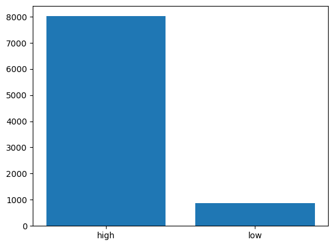

```python
rating_category_distribution = f1["Rating_Category"].value_counts()
print(rating_category_distribution)
plt.bar(["high","low"],f1["Rating_Category"].value_counts().values)
plt.show()
```

### 8. Convert the column "Reviews'' to numeric data type and check the presence of outliers in the column and handle the outliers using a transformation approach.(Hint: Use log transformation)

```python
f1['Reviews'] = pd.to_numeric(f1['Reviews'], errors='coerce')
```

```python
f1['Reviews'].dtype
```

```
dtype('int64')
```

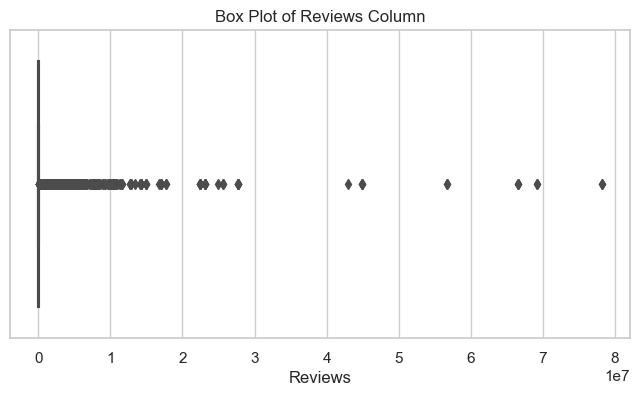

```python
sns.set(style="whitegrid")
plt.figure(figsize=(8, 4))
sns.boxplot(x=f1['Reviews'])
plt.title("Box Plot of Reviews Column")
plt.show()
```

```python
median_reviews = f1['Reviews'].median()
Q1 = f1['Reviews'].quantile(0.25)
Q3 = f1['Reviews'].quantile(0.75)
IQR = Q3 - Q1

upper_bound = Q3 + 1.5 * IQR
lower_bound = Q1 - 1.5 * IQR

f1['Reviews'] = f1['Reviews'].apply(lambda x: np.log(x) if (x > 0 and x <= upper_bound and x >= lower_bound) else median_reviews)

f1['Reviews']
```

```
0           5.068904
1           6.874198
2          11.379508
3        4714.500000
4           6.874198
            ...
10834       1.945910
10836       3.637586
10837       1.386294
10839       4.736198
10840    4714.500000
Name: Reviews, Length: 8892, dtype: float64
```

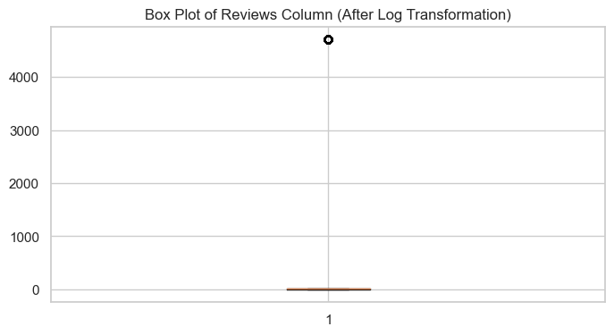

```python
sns.set(style="whitegrid")
plt.figure(figsize=(8, 4))
plt.boxplot(x=f1['Reviews'])
plt.title("Box Plot of Reviews Column (After Log Transformation)")
plt.show()
```

### 9. The column 'Size' contains alphanumeric values, treat the non numeric data and convert the column into suitable data type. (hint: Replace M with 1 million and K with 1 thousand, and drop the entries where size='Varies with device')

```python
f1 = f1[f1['Size'] != 'Varies with device']
```

```python
def replace_M_K(x):
    if "." not in str(x):
        return int(float(str(x).replace("M","000000").replace("k","000")))
    elif "M" in str(x):
        return int(float(str(x).replace("M",""))*1000000)
    elif "k" in str(x):
        return int(float(str(x).replace("k",""))*1000)

f1["Size"] = f1["Size"].apply(replace_M_K)
```

```python
f1["Size"].head(5)
```

```
0    19000000
1    14000000
2     8700000
3    25000000
4     2800000
Name: Size, dtype: int64
```

### 10. Check the column 'Installs', treat the unwanted characters and convert the column into a suitable data type

```python
f1 ["Installs"] = f1["Installs"].astype(str)
f1['Installs'].str.replace(',','').str.replace('+','')
```

```
0           10000
1          500000
2         5000000
3        50000000
4          100000
           ...
10833        1000
10834         500
10836        5000
10837         100
10840    10000000
Name: Installs, Length: 7424, dtype: object
```

```python
f1['Installs'] = pd.to_numeric(f1['Installs'], errors = 'coerce')
f1['Installs'].dtype
```

```
dtype('float64')
```

### 11. Check the column 'Price' , remove the unwanted characters and convert the column into a suitable data type

```python
f1 ["Price"] = f1["Price"].astype(str)
f1["Price"].str.replace('$', '')
```

```
0        0
1        0
2        0
3        0
4        0
        ..
10833    0
10834    0
10836    0
10837    0
10840    0
Name: Price, Length: 7424, dtype: object
```

```python
f1['Price'] = pd.to_numeric(f1['Price'],errors = 'coerce')
```

```python
f1["Price"].dtype
```

```
dtype('float64')
```

### 12. Drop the columns which you think redundant for the analysis.(suggestion: drop column 'rating', since we created a new feature from it (i.e. rating_category) and the columns 'App', 'Rating' ,'Genres','Last Updated', 'Current Ver','Android Ver' columns since which are redundant for our analysis)

```python
f1 = f1.drop(['App','Rating','Genres','Last Updated', 'Current Ver','Android Ver' ], axis = 1)
```

```python
f1.head(10)
```

|  | Category | Reviews | Size | Installs | Type | Price | Content Rating | Rating_Category |
| --- | --- | --- | --- | --- | --- | --- | --- | --- |
| 0 | ART_AND_DESIGN | 5.068904 | 19000000 | NaN | Free | 0.0 | Everyone | high |
| 1 | ART_AND_DESIGN | 6.874198 | 14000000 | NaN | Free | 0.0 | Everyone | high |
| 2 | ART_AND_DESIGN | 11.379508 | 8700000 | NaN | Free | 0.0 | Everyone | high |
| 3 | ART_AND_DESIGN | 4714.500000 | 25000000 | NaN | Free | 0.0 | Teen | high |
| 4 | ART_AND_DESIGN | 6.874198 | 2800000 | NaN | Free | 0.0 | Everyone | high |
| 5 | ART_AND_DESIGN | 5.117994 | 5600000 | NaN | Free | 0.0 | Everyone | high |
| 6 | ART_AND_DESIGN | 5.181784 | 19000000 | NaN | Free | 0.0 | Everyone | high |
| 7 | ART_AND_DESIGN | 10.513661 | 29000000 | NaN | Free | 0.0 | Everyone | high |
| 8 | ART_AND_DESIGN | 9.531771 | 33000000 | NaN | Free | 0.0 | Everyone | high |
| 9 | ART_AND_DESIGN | 4.795791 | 3100000 | NaN | Free | 0.0 | Everyone | high |

### 13. Encode the categorical columns.

```python
label_encoder = LabelEncoder()
f1['Type'] = label_encoder.fit_transform(f1['Type'])
f1['Content Rating'] = label_encoder.fit_transform(f1['Content Rating'])
f1['Rating_Category'] = label_encoder.fit_transform(f1['Rating_Category'])
f1['Category'] = label_encoder.fit_transform(f1['Category'])
f1.head(10)
```

|  | Category | Reviews | Size | Installs | Type | Price | Content Rating | Rating_Category |
| --- | --- | --- | --- | --- | --- | --- | --- | --- |
| 0 | 0 | 5.068904 | 19000000 | NaN | 0 | 0.0 | 1 | 0 |
| 1 | 0 | 6.874198 | 14000000 | NaN | 0 | 0.0 | 1 | 0 |
| 2 | 0 | 11.379508 | 8700000 | NaN | 0 | 0.0 | 1 | 0 |
| 3 | 0 | 4714.500000 | 25000000 | NaN | 0 | 0.0 | 4 | 0 |
| 4 | 0 | 6.874198 | 2800000 | NaN | 0 | 0.0 | 1 | 0 |
| 5 | 0 | 5.117994 | 5600000 | NaN | 0 | 0.0 | 1 | 0 |
| 6 | 0 | 5.181784 | 19000000 | NaN | 0 | 0.0 | 1 | 0 |
| 7 | 0 | 10.513661 | 29000000 | NaN | 0 | 0.0 | 1 | 0 |
| 8 | 0 | 9.531771 | 33000000 | NaN | 0 | 0.0 | 1 | 0 |
| 9 | 0 | 4.795791 | 3100000 | NaN | 0 | 0.0 | 1 | 0 |

### 14. Segregate the target and independent features (Hint: Use Rating_category as the target)

```python
x = f1.drop("Rating_Category", axis=1)
y = f1["Rating_Category"]
```

### 15. Split the dataset into train and test.

```python
X_train, X_test, y_train, y_test = train_test_split(x,y, test_size=0.30, random_state=42)

print(X_train.shape,X_test.shape)
print(y_train.shape,y_test.shape)
```

```
(5196, 7) (2228, 7)
(5196,) (2228,)
```

### 16. Standardize the data, so that the values are within a particular range

```python
scaler = MinMaxScaler(feature_range=(0, 1))

# Fit and transform the scaler on the training set
X_train_scaled = scaler.fit_transform(X_train)

# Transform the test set using the same scaler
X_test_scaled = scaler.transform(X_test)
```

```python
X_train.head(5)
```

|  | Category | Reviews | Size | Installs | Type | Price | Content Rating |
| --- | --- | --- | --- | --- | --- | --- | --- |
| 6799 | 27 | 5.062595 | 26000000 | NaN | 0 | 0.0 | 3 |
| 428 | 6 | 4714.500000 | 11000000 | NaN | 0 | 0.0 | 1 |
| 3304 | 29 | 9.424484 | 5300000 | NaN | 0 | 0.0 | 1 |
| 5662 | 28 | 2.833213 | 14000000 | NaN | 0 | 0.0 | 1 |
| 3714 | 31 | 10.561784 | 89000000 | NaN | 0 | 0.0 | 1 |

```python
X_test.head(5)
```

|  | Category | Reviews | Size | Installs | Type | Price | Content Rating |
| --- | --- | --- | --- | --- | --- | --- | --- |
| 1867 | 14 | 4714.500000 | 81000000 | NaN | 0 | 0.0 | 4 |
| 4414 | 14 | 4.382027 | 7600000 | NaN | 0 | 0.0 | 1 |
| 116 | 2 | 4.304065 | 2900000 | NaN | 0 | 0.0 | 1 |
| 7608 | 11 | 10.575232 | 98000000 | NaN | 0 | 0.0 | 1 |
| 9463 | 11 | 10.794071 | 68000000 | NaN | 0 | 0.0 | 1 |

## PART 2

### 1. Import required libraries and read the dataset.

```python
import pandas as pd
import numpy as np
import seaborn as sns
import matplotlib.pyplot as plt
from sklearn.linear_model import LinearRegression
from sklearn.model_selection import train_test_split
from sklearn.preprocessing import LabelEncoder
from sklearn.preprocessing import MinMaxScaler
```

```python
f2 = pd.read_csv("honeyproduction.csv")
```

### 2. Check the first few samples, shape, info of the data and try to familiarize yourself with different features.

```python
f2.head(5)
```

|  | state | numcol | yieldpercol | totalprod | stocks | priceperlb | prodvalue | year |
| --- | --- | --- | --- | --- | --- | --- | --- | --- |
| 0 | AL | 16000.0 | 71 | 1136000.0 | 159000.0 | 0.72 | 818000.0 | 1998 |
| 1 | AZ | 55000.0 | 60 | 3300000.0 | 1485000.0 | 0.64 | 2112000.0 | 1998 |
| 2 | AR | 53000.0 | 65 | 3445000.0 | 1688000.0 | 0.59 | 2033000.0 | 1998 |
| 3 | CA | 450000.0 | 83 | 37350000.0 | 12326000.0 | 0.62 | 23157000.0 | 1998 |
| 4 | CO | 27000.0 | 72 | 1944000.0 | 1594000.0 | 0.70 | 1361000.0 | 1998 |

```python
f2.tail(5)
```

|  | state | numcol | yieldpercol | totalprod | stocks | priceperlb | prodvalue | year |
| --- | --- | --- | --- | --- | --- | --- | --- | --- |
| 621 | VA | 4000.0 | 41 | 164000.0 | 23000.0 | 3.77 | 618000.0 | 2012 |
| 622 | WA | 62000.0 | 41 | 2542000.0 | 1017000.0 | 2.38 | 6050000.0 | 2012 |
| 623 | WV | 6000.0 | 48 | 288000.0 | 95000.0 | 2.91 | 838000.0 | 2012 |
| 624 | WI | 60000.0 | 69 | 4140000.0 | 1863000.0 | 2.05 | 8487000.0 | 2012 |
| 625 | WY | 50000.0 | 51 | 2550000.0 | 459000.0 | 1.87 | 4769000.0 | 2012 |

```python
f2.shape
```

```
(626, 8)
```

```python
f2.info()
```

```
<class 'pandas.core.frame.DataFrame'>
RangeIndex: 626 entries, 0 to 625
Data columns (total 8 columns):
 #   Column       Non-Null Count  Dtype
---  ------       --------------  -----
 0   state        626 non-null    object
 1   numcol       626 non-null    float64
 2   yieldpercol  626 non-null    int64
 3   totalprod    626 non-null    float64
 4   stocks       626 non-null    float64
 5   priceperlb   626 non-null    float64
 6   prodvalue    626 non-null    float64
 7   year         626 non-null    int64
dtypes: float64(5), int64(2), object(1)
memory usage: 39.2+ KB
```

```python
f2.describe()
```

|  | numcol | yieldpercol | totalprod | stocks | priceperlb | prodvalue | year |
| --- | --- | --- | --- | --- | --- | --- | --- |
| count | 626.000000 | 626.000000 | 6.260000e+02 | 6.260000e+02 | 626.000000 | 6.260000e+02 | 626.000000 |
| mean | 60284.345048 | 62.009585 | 4.169086e+06 | 1.318859e+06 | 1.409569 | 4.715741e+06 | 2004.864217 |
| std | 91077.087231 | 19.458754 | 6.883847e+06 | 2.272964e+06 | 0.638599 | 7.976110e+06 | 4.317306 |
| min | 2000.000000 | 19.000000 | 8.400000e+04 | 8.000000e+03 | 0.490000 | 1.620000e+05 | 1998.000000 |
| 25% | 9000.000000 | 48.000000 | 4.750000e+05 | 1.430000e+05 | 0.932500 | 7.592500e+05 | 2001.000000 |
| 50% | 26000.000000 | 60.000000 | 1.533000e+06 | 4.395000e+05 | 1.360000 | 1.841500e+06 | 2005.000000 |
| 75% | 63750.000000 | 74.000000 | 4.175250e+06 | 1.489500e+06 | 1.680000 | 4.703250e+06 | 2009.000000 |
| max | 510000.000000 | 136.000000 | 4.641000e+07 | 1.380000e+07 | 4.150000 | 6.961500e+07 | 2012.000000 |

### 3. Display the percentage distribution of the data in each year using the pie chart

```python
percentage_distribution_year_wise = (f2.groupby(by='year').size()/len(f2))*100
percentage_distribution_year_wise
```

```
year
1998    6.869010
1999    6.869010
2000    6.869010
2001    7.028754
2002    7.028754
2003    7.028754
2004    6.549521
2005    6.549521
2006    6.549521
2007    6.549521
2008    6.549521
2009    6.389776
2010    6.389776
2011    6.389776
2012    6.389776
dtype: float64
```

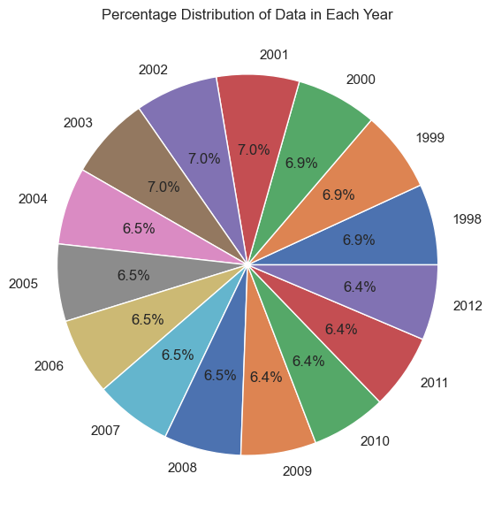

```python
plt.figure(figsize=(7,7))
plt.pie(percentage_distribution_year_wise,labels=percentage_distribution_year_wise.index,autopct='%1.1f%%')
plt.title('Percentage Distribution of Data in Each Year')
plt.show()
```

### 4. Plot and Understand the distribution of the variable "price per lb" using displot, and write your findings.

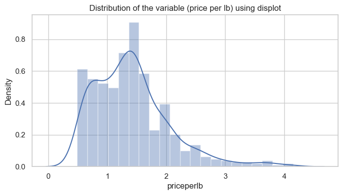

```python
plt.figure(figsize=(8,4))
sns.distplot(f2['priceperlb'])
plt.title("Distribution of the variable (price per lb) using displot")
plt.show()
```

### 5. Plot and understand the relationship between the variables 'numcol' and 'prodval' through scatterplot, and write your findings.

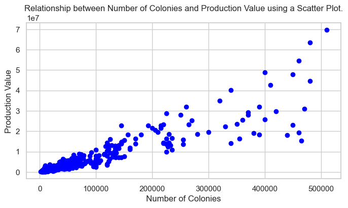

```python
plt.figure(figsize=(8,4))
plt.scatter(f2['numcol'],f2['prodvalue'],color="blue")
plt.xlabel("Number of Colonies")
plt.ylabel("Production Value")
plt.title('Relationship between Number of Colonies and Production Value using a Scatter Plot.')
plt.show()
```

Inference - we can say that the variable's numcol and prodval are having a direct relationship i.e they are positively correlated. means, as the number of colonies increases, the production value of honey also increases.

### 6. Plot and understand the relationship between categorical variable 'year' and a numerical variable 'prodvalue' through boxplot, and write your findings.

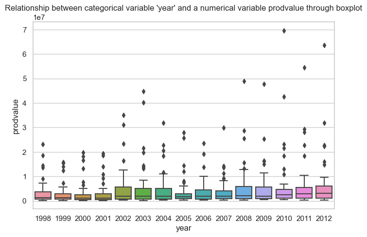

```python
plt.figure(figsize=(8,5))
sns.boxplot(x="year", y="prodvalue",data=f2)
plt.title("Relationship between categorical variable 'year' and a numerical variable prodvalue through boxplot")
plt.show()
```

### 7. Visualize and understand the relationship between the multiple pairs of variables throughout different years using pairplot and add your inferences. (use columns 'numcol', 'yield percol', 'total prod', 'prodvalue','year')

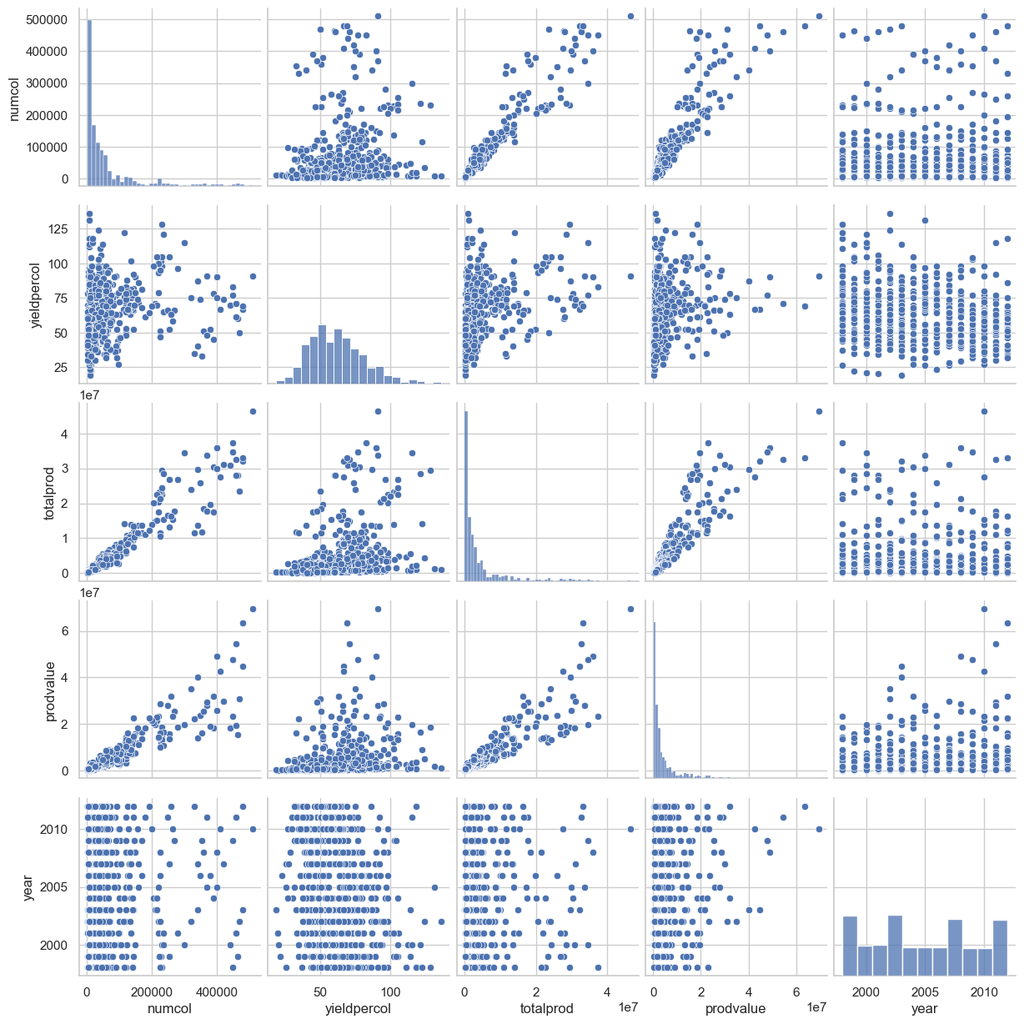

```python
sns.pairplot(f2, vars=['numcol', 'yieldpercol', 'totalprod', 'prodvalue', 'year'])
plt.show()
```

### 8. Display the correlation values using a plot and add your inferences. (use columns 'numcol', 'yield percol', 'total prod', 'stocks', 'price per lb', 'prodvalue')

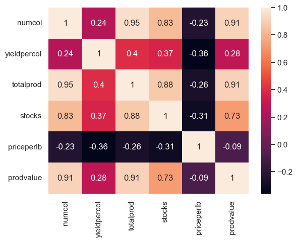

```python
sns.heatmap(f2[['numcol', 'yieldpercol','totalprod', 'stocks', 'priceperlb', 'prodvalue']].corr(),annot=True)
```

Inference - we can see that increase in yieldpercol results decrease in priceperlb. The heatmap is illustrating negative correlation.